# Homework 9.2: Caulobacter growth (65 pts)

[Data download](https://s3.amazonaws.com/bebi103.caltech.edu/data/caulobacter_growth_events.csv)

In this problem, we will study the growth and division of *Caulobacter crescentus* over time. The lab of [Norbert Scherer](http://schererlab.uchicago.edu) at the University of Chicago acquired these data and published the work in PNAS, which you can download [here](https://doi.org/10.1073/pnas.1403232111).

The clever experimental set-up allows imaging of single dividing cells in conditions that are identical through time. This is accomplished by taking advantage of a unique morphological feature of *Caulobacter*. The mother cell is adherent to the a surface through its stalk. Upon division, one of the daughter cells does not have a stalk and is mobile. The system is part of a microfluidic device that gives a constant flow. So, every time a mother cell divides, the un-stalked daughter cell gets washed away. In such a way, the dividing cells are never in a crowded environment and the buffer is always fresh. This also allows for easier segmentation.

We define a growth event as a time period during which a bacterium grows before dividing. After a division, a new growth event begins. Based on image data kindly provided by Charlie Wright and [Sri Iyer-Biswas](https://iyerbiswas.com), I processed the images to get a set of growth events. The data are available here: https://s3.amazonaws.com/bebi103.caltech.edu/data/caulobacter_growth_events.csv.

It is well known that in ideal conditions, bacteria grow exponentially. One bacterium divides to form two, those two divide to form four, those four divide to form eight, and so on. But what about each individual growth event? How does a single cell grow?

**a)** One theoretical model we will consider is that each the growth of an individual bacterium is linear. That is,

\begin{align} a(t) = a_0(1 + k t), \end{align}

where $a$ denotes the area observed in the microscope images. An alternative model is that each individual bacterium grows exponentially, such that

\begin{align} a(t) = a_0\mathrm{e}^{kt}. \end{align}

Considering each growth event to be independent of all others, develop a generative model for each of the two theoretical models. Comment on any considerations you made and concerns you may have with your modeling procedures.

**b)** Using this model, perform parameter estimates for $a_0$ and $k$ for each growth event separately. Think about how to display your results graphically and make informative graphics.

**c)** Compare the two models. Do you think growth is exponential or linear?

### Import libraries and prepare data

```python
import warnings
import os

import numpy as np
import pandas as pd
import scipy.optimize
import scipy.stats as st
from scipy.special import erf
import colorcet
# import bebi103
import tqdm

import bokeh.io
from bokeh.plotting import figure, show
from bokeh.layouts import row
from bokeh.transform import jitter
import iqplot
bokeh.io.output_notebook()
import matplotlib.pyplot as plt
%load_ext blackcellmagic
```

```
The blackcellmagic extension is already loaded. To reload it, use:
  %reload_ext blackcellmagic
```

```python
data_path= "../Data/"
df = pd.read_csv(os.path.join(data_path, 'caulobacter_growth_events.csv'), header=0)
df
```

|  | time (min) | area (µm²) | bacterium | growth event |
| --- | --- | --- | --- | --- |
| 0 | 1.0 | 1.300624 | 1 | 0 |
| 1 | 2.0 | 1.314144 | 1 | 0 |
| 2 | 3.0 | 1.295216 | 1 | 0 |
| 3 | 4.0 | 1.314144 | 1 | 0 |
| 4 | 5.0 | 1.341184 | 1 | 0 |
| ... | ... | ... | ... | ... |
| 10316 | 8695.0 | 1.633216 | 2 | 86 |
| 10317 | 8696.0 | 1.638624 | 2 | 86 |
| 10318 | 8697.0 | 1.644032 | 2 | 86 |
| 10319 | 8698.0 | 1.657552 | 2 | 86 |
| 10320 | 8699.0 | 1.684592 | 2 | 86 |

10321 rows × 4 columns

Adding time since growth event beginning

```python
gb=df.groupby(['bacterium', 'growth event'])
t =[gb.get_group(x) for x in gb.groups]

for i in t:
    start_time=i['time (min)'].values[0]
    i['growth_time']=i['time (min)']-start_time
df=pd.concat(t)
warnings.filterwarnings('once')
df
```

|  | time (min) | area (µm²) | bacterium | growth event | growth_time |
| --- | --- | --- | --- | --- | --- |
| 0 | 1.0 | 1.300624 | 1 | 0 | 0.0 |
| 1 | 2.0 | 1.314144 | 1 | 0 | 1.0 |
| 2 | 3.0 | 1.295216 | 1 | 0 | 2.0 |
| 3 | 4.0 | 1.314144 | 1 | 0 | 3.0 |
| 4 | 5.0 | 1.341184 | 1 | 0 | 4.0 |
| ... | ... | ... | ... | ... | ... |
| 10316 | 8695.0 | 1.633216 | 2 | 86 | 33.0 |
| 10317 | 8696.0 | 1.638624 | 2 | 86 | 34.0 |
| 10318 | 8697.0 | 1.644032 | 2 | 86 | 35.0 |
| 10319 | 8698.0 | 1.657552 | 2 | 86 | 36.0 |
| 10320 | 8699.0 | 1.684592 | 2 | 86 | 37.0 |

10321 rows × 5 columns

group by bacterium and add to list (first is bacterium 1, second is bacterium 2)

```python
gb=df.groupby(['bacterium'])
first, second =[gb.get_group(x) for x in gb.groups]
```

group by growth event for bacterium 1

```python
gb1=first.groupby(['growth event'])
lst1 =[gb1.get_group(x) for x in gb1.groups]
```

group by growth event for bacterium 2

```python
gb2=second.groupby(['growth event'])
lst2 =[gb2.get_group(x) for x in gb2.groups]
```

### EDA

```python
# Bacterium 1 plot to visualize all events
```

```python
# Bacterium 1 Plot

p = bokeh.plotting.figure(
    x_axis_label="growth_time",
    y_axis_label="area (µm²)",
    frame_height=400,
    frame_width=450,
)

# Colors for trails
colors = colorcet.b_glasbey_category10

for gevent, g in first.groupby("growth event"):
    p.circle(
        x="growth_time",
        y="area (µm²)",
        source=g,
        size=2,
        color=colors[gevent],
        legend_label=f"growth event {gevent}",
    )

p.title.text = 'Bacterium 1'
p.add_layout(p.legend[0], 'right')
p.legend.spacing = 1
p.legend.padding = 1
p.legend.click_policy="mute"

bokeh.io.show(p)
```

[interactive chart not shown]

```python
# Bacterium 2 Plot

p2 = bokeh.plotting.figure(
    x_axis_label="growth_time",
    y_axis_label="area (µm²)",
    frame_height=400,
    frame_width=450,
)

# Colors for trails
colors = colorcet.b_glasbey_category10

for gevent, g in second.groupby("growth event"):
    p2.circle(
        x="growth_time",
        y="area (µm²)",
        source=g,
        size=2,
        color=colors[gevent],
        legend_label=f"growth event {gevent}",
    )

p2.title.text = 'Bacterium 2'
p2.add_layout(p2.legend[0], 'right')
p2.legend.spacing = 1
p2.legend.padding = 1
p2.legend.click_policy="mute"

bokeh.io.show(p2)
```

[interactive chart not shown]

Plot ecdfs for both bacteria

```python
f=iqplot.ecdf(first['area (µm²)'].values, title='Bacterium 1', conf_int=True)
s=iqplot.ecdf(second['area (µm²)'].values, title='Bacterium 2', conf_int=True)
bokeh.io.show(row(f,s))
```

[interactive chart not shown]

plot all growth events separately for bacterium 1

```python
plots = [
    bokeh.plotting.figure(
        x_axis_label="growth_time",
        y_axis_label="area (µm²)",
        frame_height=150,
        frame_width=200,
        title=f"growth event {gevent}",
    )
    for gevent in first["growth event"].unique()
]

for gevent, g in first.groupby("growth event"):
    plots[gevent].circle(
        x="growth_time",
        y="area (µm²)",
        source=g,
        size=2,
    )

bokeh.io.show(bokeh.layouts.gridplot(plots, ncols=3))
```

[interactive chart not shown]

plot all growth events separately for bacterium 2

```python
plots = [
    bokeh.plotting.figure(
        x_axis_label="growth_time",
        y_axis_label="area (µm²)",
        frame_height=150,
        frame_width=200,
        title=f"growth event {gevent}",
    )
    for gevent in second["growth event"].unique()
]

for gevent, g in second.groupby("growth event"):
    plots[gevent].circle(
        x="growth_time",
        y="area (µm²)",
        source=g,
        size=2,
    )

bokeh.io.show(bokeh.layouts.gridplot(plots, ncols=3))
```

[interactive chart not shown]

## Part A :

As many processes are involved in cell growth, we choose to model the area it occupies in the microscope as being Normally distributed. We also assume that the area of each cell we measure is independent of all of the other cells we measure, and further that the distribution we use to describe the cell area of any given egg is the same as any other. That is to say that the areas of the cells are independent and identically distributed, abbreviated i.i.d.

$f(\{t_{ijk}, a_{ijk}\};\{a_0, k, \sigma\}) = \prod_{ijk} \frac{1}{\sqrt{2\pi\sigma}}exp[-\frac{1}{2\sigma\mu^2}(a_{ijk} - a(t_{ijk}a-k_{jk}))^2]$  
$l(\{a_0, k, \sigma\};\{t_{ijk}, a_{ijk}\}) = -\frac{1}{2}\sum_{ijk}ln2\pi-\sum_{ijk}[ln\sigma_{jk}+\frac{1}{2\sigma_{jk}}(a_{ijk} - a(t_{ijk}a-k_{jk}))^2]$  
$l(\{a_0, k, \sigma\};\{t_{ijk}, a_{ijk}\}) = -\frac{1}{2}\sum_{ijk}ln2\pi-\sum_{k}\sum_{j}[ln\sigma_{jk}+\frac{1}{2\sigma_{jk}}(a_{ijk} - a(t_{ijk}a-k_{jk}))^2]$

### Comment on any considerations you made and concerns you may have with your modeling procedures:

The two models are similar to each other. In fact, if we write the exponential equation as a Taylor series and truncate at the first term, we get the linear equation. Another point of consideration is the regime from which we collected the measurements. Essentially exponential growth can be seen as linear if we "zoom in" in time enough. So even in the cases where the linear model works better, we cannot rule out the scenario of exponential growth.

```python
def gen_normal(mu, sigma, n):
    return  np.random.normal(mu, sigma, n)
```

### Functions for linear growth model

```python
def log_normal_linear(params, data):
    """
    data should contain 1) paramas and 2) both time and area. In this order.
    """
    t=data[0]
    area=data[1]

    a0, k, sigma = params

    mu = a0+a0*k*t

    if mu.any() < 0 or sigma <= 0 or a0<=0.01 or k<=0: # no parameter can be negative
        return -np.inf

    return np.sum(st.norm.logpdf(area, mu, sigma))


def mle_iid_norm_linear(data):
    """Perform maximum likelihood estimates for parameters for i.i.d. norm measurements, parametrized by mu (ff, fb, koff, D) and sigma"""
    with warnings.catch_warnings():
        warnings.simplefilter("ignore")

        res = scipy.optimize.minimize(
            fun=lambda params, data: -log_normal_linear(params, data),
            x0=np.array([0.9, 0.01, 0.1]),   # initial guesses
            args=(data,),
            method='Powell'
            # bounds=((0,1), (0,1), (0,np.inf),(0,np.inf), (0,np.inf))
        )
    if res.success:
        return res.x
    else:
        raise RuntimeError('Convergence failed with message', res.message)

def draw_parametric_bs_reps_mle_linear(
    mle_fun, gen_fun, data, args=(), reps=1, progress_bar=False
):
    """
    Draw parametric bootstrap replicates of maximum likelihood estimator.
    """

    t=data[0]
    area=data[1]
    a0, k, sigma = mle_fun(data)
    mu = a0+a0*k*t

    if progress_bar:
        iterator = tqdm.tqdm(range(reps))
    else:
        iterator = range(reps)

    return np.array([mle_fun([t,gen_fun(mu, sigma, n=len(mu))]) for _ in iterator])
```

Functions for Exponential Growth Model

```python
def log_normal_exp(params, data):
    """
    data should contain 1) paramas and 2) both time and area. In this order.
    """
    t=data[0]
    area=data[1]

    a0, k, sigma = params

    mu = a0*np.exp(k*t)

    if mu.any() < 0 or sigma <= 0 or a0<=0.01 or k<=0: # no parameter can be negative
        return -np.inf

    return np.sum(st.norm.logpdf(area, mu, sigma))



def mle_iid_norm_exp(data):
    """Perform maximum likelihood estimates for parameters for i.i.d. norm measurements, parametrized by mu (ff, fb, koff, D) and sigma"""
    with warnings.catch_warnings():
        warnings.simplefilter("ignore")

        res = scipy.optimize.minimize(
            fun=lambda params, data: -log_normal_exp(params, data),
            x0=np.array([0.9, 0.01, 0.1]),   # 5 initial guesses in this order  ff, fb, koff, D, sigma
            args=(data,),
            method='Powell'
            # bounds=((0,1), (0,1), (0,np.inf),(0,np.inf), (0,np.inf))
        )
    if res.success:
        return res.x
    else:
        raise RuntimeError('Convergence failed with message', res.message)


def draw_parametric_bs_reps_mle_exp(
    mle_fun, gen_fun, data, args=(), reps=1, progress_bar=False
):
    """
    Draw parametric bootstrap replicates of maximum likelihood estimator.
    """

    t=data[0]
    area=data[1]
    a0, k, sigma = mle_fun(data)
    mu = a0*np.exp(k*t)

    if progress_bar:
        iterator = tqdm.tqdm(range(reps))
    else:
        iterator = range(reps)

    return np.array([mle_fun([t,gen_fun(mu, sigma, n=len(mu))]) for _ in iterator])
```

Running parameter estimation to get MLEs and bootstraps for Bacterium 1 using the linear model

```python
df_mle_normal_1_l = pd.DataFrame(
    columns=["bacterium", "model", "growth event","parameter","mle","lower","upper"]
)

params_bootstrap_1_l=[]

for i in lst1:
    data=[i['growth_time'][i['growth_time']>=0], i['area (µm²)'][i['growth_time']>=0]]

    #obtaining the MLE of the  parameters
    a0, k, sigma = mle_iid_norm_linear(data)

    #obtaining parametric bootstrap replicates for each experiment
    fo_bs_reps_parametric_1_l = draw_parametric_bs_reps_mle_linear(
        mle_iid_norm_linear,
        gen_normal,
        data,
        args=(),
        reps=10,
        progress_bar=True,
    )
    params_bootstrap_1_l.append(fo_bs_reps_parametric_1_l)

    # obtaining the 95% CI upper and lower bound for each parameter
    [lower_a0, lower_k, lower_sigma], [
        upper_a0,
        upper_k,
        upper_sigma
    ] = np.percentile(fo_bs_reps_parametric_1_l, [2.5, 97.5], axis=0)

    sub_df_1_l = pd.DataFrame(
        {
            "bacterium": ["1", "1", "1"],
            "model": ["linear", "linear", "linear"],
            "growth event": str(i['growth event'].iloc[0]+1),
            "parameter": ["a0", "k", "σ"],
            "mle": [a0, k, sigma],
            "lower": [lower_a0, lower_k, lower_sigma],
            "upper": [upper_a0, upper_k, upper_sigma],
        }
    )
    df_mle_normal_1_l= pd.concat([df_mle_normal_1_l, sub_df_1_l])
```

```python
df_mle_normal_1_l.head()
```

|  | bacterium | model | growth event | parameter | mle | lower | upper |
| --- | --- | --- | --- | --- | --- | --- | --- |
| 0 | 1 | linear | 1 | a0 | 1.248918 | 1.240981 | 1.257189 |
| 1 | 1 | linear | 1 | k | 0.008699 | 0.008548 | 0.008872 |
| 2 | 1 | linear | 1 | σ | 0.031298 | 0.027167 | 0.033685 |
| 0 | 1 | linear | 2 | a0 | 1.292370 | 1.281620 | 1.307886 |
| 1 | 1 | linear | 2 | k | 0.008738 | 0.008496 | 0.008961 |

Running parameter estimation to get MLEs and bootstraps for Bacterium 1 using the exponential model

```python
df_mle_normal_1_exp = pd.DataFrame(
    columns=["bacterium", "model", "growth event","parameter","mle","lower","upper"]
)

params_bootstrap_1_exp=[]

for i in lst1:
    data=[i['growth_time'][i['growth_time']>=0], i['area (µm²)'][i['growth_time']>=0]]

    #obtaining the MLE of the  parameters
    a0, k, sigma = mle_iid_norm_exp(data)

    #obtaining parametric bootstrap replicates for each experiment
    fo_bs_reps_parametric_1_exp = draw_parametric_bs_reps_mle_exp(
        mle_iid_norm_exp,
        gen_normal,
        data,
        args=(),
        reps=10,
        progress_bar=True,
    )
    params_bootstrap_1_exp.append(fo_bs_reps_parametric_1_exp)

    # obtaining the 95% CI upper and lower bound for each parameter
    [lower_a0, lower_k, lower_sigma], [
        upper_a0,
        upper_k,
        upper_sigma
    ] = np.percentile(fo_bs_reps_parametric_1_exp, [2.5, 97.5], axis=0)

    sub_df_1_exp = pd.DataFrame(
        {
            "bacterium": ["1", "1", "1"],
            "model": ["exp", "exp", "exp"],
            "growth event": str(i['growth event'].iloc[0]+1),
            "parameter": ["a0", "k", "σ"],
            "mle": [a0, k, sigma],
            "lower": [lower_a0, lower_k, lower_sigma],
            "upper": [upper_a0, upper_k, upper_sigma],
        }
    )
    df_mle_normal_1_exp= pd.concat([df_mle_normal_1_exp, sub_df_1_exp])
```

```python
df_mle_normal_1_exp.head()
```

|  | bacterium | model | growth event | parameter | mle | lower | upper |
| --- | --- | --- | --- | --- | --- | --- | --- |
| 0 | 1 | exp | 1 | a0 | 1.296799 | 1.295115 | 1.300567 |
| 1 | 1 | exp | 1 | k | 0.006168 | 0.006115 | 0.006179 |
| 2 | 1 | exp | 1 | σ | 0.013948 | 0.012853 | 0.015355 |
| 0 | 1 | exp | 2 | a0 | 1.337626 | 1.329447 | 1.340627 |
| 1 | 1 | exp | 2 | k | 0.006262 | 0.006224 | 0.006344 |

Bacterium 2 linear

```python
df_mle_normal_2_l = pd.DataFrame(
    columns=["bacterium", "model", "growth event","parameter","mle","lower","upper"]
)

params_bootstrap_2_l=[]

for i in lst2:
    data=[i['growth_time'][i['growth_time']>=0], i['area (µm²)'][i['growth_time']>=0]]

    #obtaining the MLE of the  parameters
    a0, k, sigma = mle_iid_norm_linear(data)

    #obtaining parametric bootstrap replicates for each experiment
    fo_bs_reps_parametric_2_l = draw_parametric_bs_reps_mle_linear(
        mle_iid_norm_linear,
        gen_normal,
        data,
        args=(),
        reps=10,
        progress_bar=True,
    )
    params_bootstrap_2_l.append(fo_bs_reps_parametric_2_l)

    # obtaining the 95% CI upper and lower bound for each parameter
    [lower_a0, lower_k, lower_sigma], [
        upper_a0,
        upper_k,
        upper_sigma
    ] = np.percentile(fo_bs_reps_parametric_2_l, [2.5, 97.5], axis=0)

    sub_df_2_l = pd.DataFrame(
        {
            "bacterium": ["2", "2", "2"],
            "model": ["linear", "linear", "linear"],
            "growth event": str(i['growth event'].iloc[0]+1),
            "parameter": ["a0", "k", "σ"],
            "mle": [a0, k, sigma],
            "lower": [lower_a0, lower_k, lower_sigma],
            "upper": [upper_a0, upper_k, upper_sigma],
        }
    )
    df_mle_normal_2_l= pd.concat([df_mle_normal_2_l, sub_df_2_l])
```

```python
df_mle_normal_2_l.head()
```

[output not shown]

Running parameter estimation to get MLEs and bootstraps for Bacterium 2 using the exponential model

```python
df_mle_normal_2_exp = pd.DataFrame(
    columns=["bacterium", "model", "growth event","parameter","mle","lower","upper"]
)

params_bootstrap_2_exp=[]

for i in lst2:
    data=[i['growth_time'][i['growth_time']>=0], i['area (µm²)'][i['growth_time']>=0]]

    #obtaining the MLE of the  parameters
    a0, k, sigma = mle_iid_norm_exp(data)

    #obtaining parametric bootstrap replicates for each experiment
    fo_bs_reps_parametric_2_exp = draw_parametric_bs_reps_mle_exp(
        mle_iid_norm_exp,
        gen_normal,
        data,
        args=(),
        reps=10,
        progress_bar=True,
    )
    params_bootstrap_2_exp.append(fo_bs_reps_parametric_2_exp)

    # obtaining the 95% CI upper and lower bound for each parameter
    [lower_a0, lower_k, lower_sigma], [
        upper_a0,
        upper_k,
        upper_sigma
    ] = np.percentile(fo_bs_reps_parametric_2_exp, [2.5, 97.5], axis=0)

    sub_df_2_exp = pd.DataFrame(
        {
            "bacterium": ["2", "2", "2"],
            "model": ["exp", "exp", "exp"],
            "growth event": str(i['growth event'].iloc[0]+1),
            "parameter": ["a0", "k", "σ"],
            "mle": [a0, k, sigma],
            "lower": [lower_a0, lower_k, lower_sigma],
            "upper": [upper_a0, upper_k, upper_sigma],
        }
    )
    df_mle_normal_2_exp= pd.concat([df_mle_normal_2_exp, sub_df_2_exp])
```

```python
df_mle_linear = pd.concat([df_mle_normal_1_l, df_mle_normal_2_l])
df_mle_exp= pd.concat([df_mle_normal_1_exp, df_mle_normal_2_exp])
```

```python
df_mle_exp
```

|  | bacterium | model | growth event | parameter | mle | lower | upper |
| --- | --- | --- | --- | --- | --- | --- | --- |
| 0 | 1 | exp | 1 | a0 | 1.296799 | 1.295115 | 1.300567 |
| 1 | 1 | exp | 1 | k | 0.006168 | 0.006115 | 0.006179 |
| 2 | 1 | exp | 1 | σ | 0.013948 | 0.012853 | 0.015355 |
| 0 | 1 | exp | 2 | a0 | 1.337626 | 1.329447 | 1.340627 |
| 1 | 1 | exp | 2 | k | 0.006262 | 0.006224 | 0.006344 |
| ... | ... | ... | ... | ... | ... | ... | ... |
| 1 | 2 | exp | 86 | k | 0.006229 | 0.006142 | 0.006274 |
| 2 | 2 | exp | 86 | σ | 0.017205 | 0.015699 | 0.019379 |
| 0 | 2 | exp | 87 | a0 | 1.330547 | 1.326301 | 1.334675 |
| 1 | 2 | exp | 87 | k | 0.006070 | 0.005931 | 0.006220 |
| 2 | 2 | exp | 87 | σ | 0.008107 | 0.005571 | 0.008966 |

321 rows × 7 columns

```python
df_mle_linear
```

|  | bacterium | model | growth event | parameter | mle | lower | upper |
| --- | --- | --- | --- | --- | --- | --- | --- |
| 0 | 1 | linear | 1 | a0 | 1.248918 | 1.240981 | 1.257189 |
| 1 | 1 | linear | 1 | k | 0.008699 | 0.008548 | 0.008872 |
| 2 | 1 | linear | 1 | σ | 0.031298 | 0.027167 | 0.033685 |
| 0 | 1 | linear | 2 | a0 | 1.292370 | 1.281620 | 1.307886 |
| 1 | 1 | linear | 2 | k | 0.008738 | 0.008496 | 0.008961 |
| ... | ... | ... | ... | ... | ... | ... | ... |
| 1 | 2 | linear | 86 | k | 0.009139 | 0.009041 | 0.009434 |
| 2 | 2 | linear | 86 | σ | 0.031291 | 0.028674 | 0.033494 |
| 0 | 2 | linear | 87 | a0 | 1.324934 | 1.320538 | 1.327598 |
| 1 | 2 | linear | 87 | k | 0.006815 | 0.006706 | 0.006992 |
| 2 | 2 | linear | 87 | σ | 0.009733 | 0.007759 | 0.010790 |

321 rows × 7 columns

Note: Only did 10 parametric bootstrap samples for each experiment for time and resources.

## Graphical assessment and visualization of the models.

Plotting growth events and their models. Only part of the events are plotted for space and time purposes.

```python
plots=[]
for i in np.arange(40, 50):
    data=[second['growth_time'][second['growth event']==i], second['area (µm²)'][second['growth event']==i]]
    a0, k, sigma = mle_iid_norm_linear(data)
    t=data[0]
    area=data[1]
    mu_l = a0+a0*k*t
    a0, k, sigma = mle_iid_norm_exp(data)
    mu_e = a0*np.exp(k*t)
    p = figure(title="Bacterium", x_axis_label='Time (s)', y_axis_label='Area')
    p.line(t, mu_l, line_color='black', line_width=5, legend_label='linear' )
    p.line(t, mu_e, line_color='gray', line_width=5, legend_label='exponential' )
    p.line(t,area, legend_label='data', line_width=4, line_color=(255,20,147))
    p.legend.location = "bottom_right"
    plots.append(p)


bokeh.io.show(bokeh.layouts.gridplot(plots, ncols=3))
```

[interactive chart not shown]

Examining visually if there are any relationships between different parameters

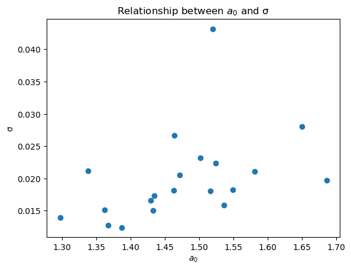

```python
a0s=df_mle_normal_1_exp['mle'][df_mle_normal_1_exp['parameter']=='a0']
ks=df_mle_normal_1_exp['mle'][df_mle_normal_1_exp['parameter']=='k']
s=df_mle_normal_1_exp['mle'][df_mle_normal_1_exp['parameter']=='σ']

plt.scatter(a0s, s)
plt.title("Relationship between $a_{0}$ and σ")
plt.xlabel("$a_{0}$")
plt.ylabel("σ")
plt.show()
```

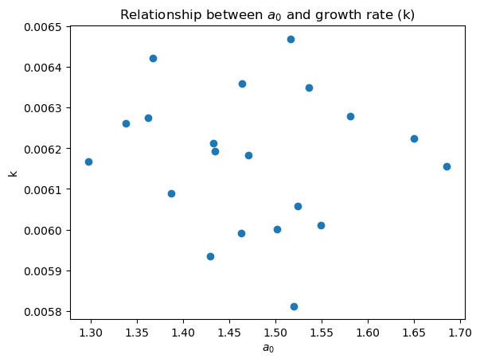

```python
plt.scatter(a0s, ks)
plt.title("Relationship between $a_{0}$ and growth rate (k)")
plt.xlabel(" $a_{0}$ ")
plt.ylabel("k")
plt.show()
```

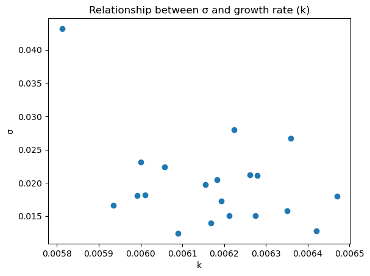

```python
plt.scatter(ks, s)
plt.title("Relationship between σ and growth rate (k)")
plt.xlabel("k")
plt.ylabel("σ")
plt.show()
```

## Part C Compare the two models. Do you think growth is exponential or linear?

```python
def Akaike(l_e, l_l, data):
    """
    input: the 3 MLEs for each experiment and the data for each experiment ([[time][area]])
    returns Akaike weight for the exponential and linear model. in this order.
    """
    l_e = log_normal_exp(l_e, data)
    l_l = log_normal_linear(l_l, data)
    AIC1 = -2 * l_e + 6
    AIC2 = -2 * l_l + 6
    w_e = 1 / (1 + np.exp(-0.5 * (AIC2 - AIC1)))
    w_l = 1 / (1 + np.exp(-0.5 * (AIC1 - AIC2)))
    return w_e, w_l
```

```python
gb=df.groupby(['bacterium', 'growth event'])
events=[gb.get_group(x) for x in gb.groups]
```

```python
Akaike_lst=[]
for i in np.arange(len(events)):
    data = [events[i]['growth_time'], events[i]['area (µm²)']]
    l_e= mle_iid_norm_exp(data)
    l_l=mle_iid_norm_linear(data)
    Akaike_lst.append(Akaike(l_e, l_l,data))
```

```python
exp_percentage = 0
for i in Akaike_lst:
    if i[0] > i[1]:
        exp_percentage += 1


print(
    "The percentage fo experiments for which the exponential generative model is better according to the Akaike weights is "
    + str(np.round(exp_percentage / len(Akaike_lst) * 100, 3))
    + " % suggesting that the exponential model is superior to the linear one."
)
```

```
The percentage fo experiments for which the exponential generative model is better according to the Akaike weights is 69.159 % suggesting that the exponential model is superior to the linear one.
```

## Functions for Exponential growth model using least squares - Extra (does not work but just adding it extra to show our work)

```python
dataZ=[lst1[1]['time (min)'][lst1[1]['time (min)']>=0], lst1[1]['area (µm²)'][lst1[1]['time (min)']>=1]] #using only data from t=0 and onwards
```

```python
t=dataZ[0]
area=dataZ[1]
```

```python
def theor_area(a0, k, t):
    """Compute mu"""
    return a0*np.exp(k*t)


def log_normal_exp(params, t, area):
    """
    data should contain 1) paramas and 2) both time and area. In this order.
    """
    a0, k, sigma = params

    mu = theor_area(a0, k, t)

    if mu.any() < 0 or sigma <= 0 or a0<=0 or k<=0: # no parameter can be negative
        return -np.inf

    return np.sum(st.norm.logpdf(area, mu, sigma))


def resid(params, t, area):
    """Residual."""
    return area - theor_area(*params, t)


def mle_iid_norm_lstsq_exp(dataZ):
    """Compute MLE for parameters."""
    # Unpack data
    t=dataZ[0]
    area=dataZ[1]

    res = scipy.optimize.least_squares(
        resid, np.array([780, 0.9]), args=(t, area)
    )

    # Compute residual sum of squares from optimal params
    rss_mle = np.sum(resid(res.x, t, area)**2)

    # Compute MLE for sigma
    sigma_mle = np.sqrt(rss_mle / len(t))

    return tuple([x for x in res.x] + [sigma_mle])


def draw_parametric_bs_reps_mle_exp(
    mle_fun, gen_fun, data, args=(), reps=1, progress_bar=False
):
    """
    Draw parametric bootstrap replicates of maximum likelihood estimator.
    """

    t=data[0]
    area=data[1]
    a0, k, sigma = mle_fun(data)
    mu = a0*np.exp(k*t)

    if progress_bar:
        iterator = tqdm.tqdm(range(reps))
    else:
        iterator = range(reps)

    return np.array([mle_fun([t,gen_fun(mu, sigma, n=len(mu))]) for _ in iterator])
```

estimation and bootstrapping (does not converge for all events)

```python
df_mle_normal_1_e = pd.DataFrame(
    columns=["bacterium", "model", "growth event","parameter","mle","lower","upper"]
)

params_bootstrap_1_e=[]

for i in lst2:
    data=[i['time (min)'][i['time (min)']>0], i['area (µm²)'][i['time (min)']>0]]

    #obtaining the MLE of the  parameters
    a0, k, sigma = mle_iid_norm_lstsq_exp(data)

    #obtaining parametric bootstrap replicates for each experiment
    fo_bs_reps_parametric_1_e = draw_parametric_bs_reps_mle_exp(
        mle_iid_norm_lstsq_exp,
        gen_normal,
        data,
        args=(),
        reps=100,
        progress_bar=True,
    )
    params_bootstrap_1_e.append(fo_bs_reps_parametric_1_e)

    # obtaining the 95% CI upper and lower bound for each parameter
    [lower_a0, lower_k, lower_sigma], [
        upper_a0,
        upper_k,
        upper_sigma
    ] = np.percentile(fo_bs_reps_parametric_1_e, [2.5, 97.5], axis=0)

    sub_df_1_e = pd.DataFrame(
        {
            "bacterium": ["1", "1", "1"],
            "model": ["exponential", "exponential", "exponential"],
            "growth event": str(i['growth event'].iloc[0]+1),
            "parameter": ["a0", "k", "σ"],
            "mle": [a0, k, sigma],
            "lower": [lower_a0, lower_k, lower_sigma],
            "upper": [upper_a0, upper_k, upper_sigma],
        }
    )
    df_mle_normal_1_e= pd.concat([df_mle_normal_1_e, sub_df_1_e])
```

**Contributions:** Panagiota and Joud worked on 9.2 and Kim worked on 9.1